# Forecasting Bus Transit Demand in El Paso, Texas

Charlie Huemmler, Yingxue Ou & Jack Rummler

2023-04-03

# Introduction

## Acknowledgement

This project was created by Charlie Huemmler, Yingxue Ou, and Jack Rummler as part of the University of Pennsylvania Master of Urban Spatial Analytics practicum. We would like to thank our client, Alex Hoffman, AICP, of the El Paso Capital Improvements Department for his continual knowledge, eagerness to help, and enthusiasm for this project. We also would like to thank Professors Matthew Harris and Michael Fichman for their invaluable mentorship throughout this process.

## Introduction and Use Case

```r
knitr::include_graphics("images/img1.png")
```

[output not shown]

> “El Paso, often forgotten, is building a stronger transit network than most US cities.” Christof Spieler (Trains, Buses, People)

Transit ridership is often a key metric to assess the efficiency of public transportation systems. Like many transit agencies in the last decade, there has been annual decreases in transit ridership, with the sharpest decline in ridership at the beginning of the COVID-19 pandemic. While many transit agencies are finally beginning to see comparable transit ridership now as compared to pre-2020, transit agencies are still grappling with how to maintain existing riders and lure new riders through trustworthy and connected service.

Sun Metro Mass Transit Department, referred to as Sun Metro, is the transportation provider in El Paso, Texas and is a department of the city of El Paso. Sun Metro has experienced a similar nationwide trend of declining ridership for several years prior to the pandemic and a sharp decrease in ridership and service during and post-pandemic. Moreover, Sun Metro has made several expansions to its transit service in the past decade, which include but are not limited to:

**Bus Rapid Transit (BRIO):** Introduced four BRIO lines between 2014 and 2022, which experience the agency’s highest ridership and most frequent service.  
**Streetcar Network:** Re-ignited the streetcar network in 2018 using restored PCC streetcars, providing more circuitous service in downtown, uptown, and University of Texas at El Paso.  
**El Paso Upper East Side Transit Center:** New transit center connected to the Five Points Transit Center, the Montana BRIO line, and more park-and-ride services.

Now, Sun Metro experiences about 63% of pre-pandemic ridership numbers, but the agency is looking to explore the implications of new bus transit alternative scenarios given its service expansions and future growth trajectory. Particularly, it is looking at ways to maximize equity and accessibility in addition to fare revenue optimization.

The balance between equity and revenue can often be a challenge for transit agencies to balance. While agencies want to provide access to transit for all of its residents, and particularly those who may be transit-dependent for all of their trips, this means placing bus stops in under-resourced neighborhoods that may not be profitable for the agency. Our client revealed that the El Paso Capital Improvements Department is looking to invest a certain percentage of annual funds toward under-resourced areas. Our group defined equity as both the ability for all El Paso residents to have reasonable access to a bus stop while prioritizing transit-dependent populations.

**Informational Network:** A scoring network to assess ridership on equity and revenue based indicators.

## El Paso Context

Sun Metro is the transportation provider in the city of El Paso, Texas. Sun Metro has made several expansions in the past decade, most notably adding four bus rapid transit (BRT) lines, adding the streetcar network, and a new transit center. With many transit agencies in the last decade, there has been a yearly decrease in bus ridership, with a sharp decrease at the start of the COVID-19 pandemic. Now, Sun Metro experiences about 63% of pre-pandemic ridership numbers, but the agency is looking to explore the implications of new bus transit services.

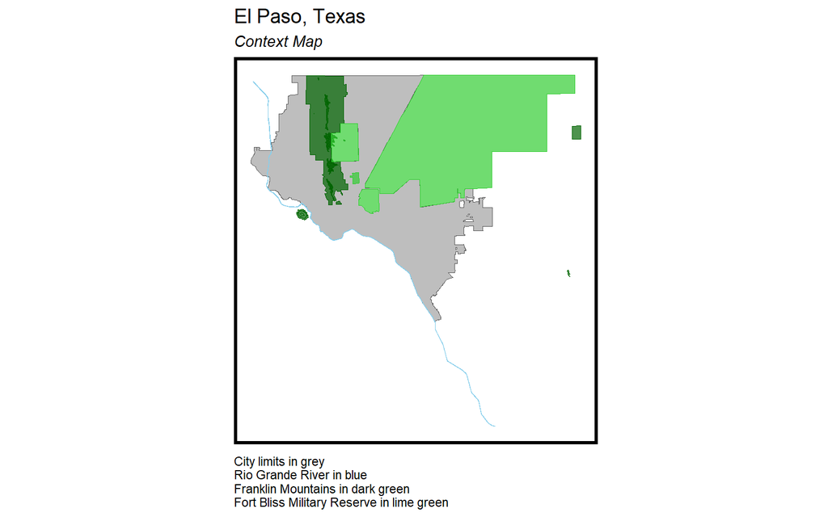

```r
plot <- ggplot() +
  geom_sf(data=el_paso, fill="grey") +
  geom_sf(data=rio, fill="skyblue", color="skyblue", size=500) +
  geom_sf(data=franklin, fill="darkgreen", color="darkgreen", alpha=0.7) +
  geom_sf(data=ft_bliss, fill="limegreen", color="limegreen", alpha=0.7) +
  labs(title="El Paso, Texas",
       subtitle="Context Map",
       caption="City limits in grey \nRio Grande River in blue \nFranklin Mountains in dark green \nFort Bliss Military Reserve in lime green")+
  mapTheme

plot
```

## Methodology

For this project, we are building a latent bus transit demand model. From the data we are supplied of on-boarding and off-boarding per route, stop, and day, we built a model to predict bus transit ridership. How this gets completed is through training our model on an 80% subset of our data and testing it on 20% of our data to receive predicted ridership.

Our data is aggregated to hexbins, which are equally shaped hexbins that act as an overlay on top of the city of El Paso boundary. Total ridership is aggregated into each hexbin to predict what the total ridership is based on the features engineered into our model. We are building three models: a logistic regression model, a Random Forest model, and an XGBoost model. 3 We are building this model to inform our client’s interest in knowing how bus transit alternative routes will affect route-level and system-level equity and fare revenue implications. In our model, we bake in equity metrics, which highlight the ability for transit-dependent populations to have operable, efficient service, in addition to the accessibility of stops for all El Paso residents. Fare revenue optimization is derived from how profit can be increased based upon new ridership patterns. If our model can accurately predict bus transit ridership, it can inform how new transit routes perform on these indicators, which the web application we develop will evaluate.

Thus, this project is two-fold: a predictive bus transit ridership model and a performance-based measurement evaluating the equity and financial implications of transit demand.

# Exploratory Data Analysis

Our client has provided us with a CSV file containing ridership data for the year 2022. The data was collected using sensors that recorded the number of on-board and off-board passengers at each stop and route on a daily basis. Approximately 85% of buses were equipped with these sensors, and they were rotated among buses to obtain the most accurate measurements.

We have aggregated this data to calculate average and total ridership for both routes and stops in order to understand the overall and spatial characteristics of ridership patterns in El Paso.

```r
ridership$Date <- ridership$Date %>%
  as.character() %>%
  substring(2) %>%
  as.Date(format = "%Y%m%d")

df <- riderstops %>%
  na.omit(riderstops[, c("stop_lat", "stop_lon")]) %>%
  st_as_sf(coords = c("stop_lon", "stop_lat"), crs = 4269)

df$longitude <- st_coordinates(df$geometry)[, "X"]
df$latitude <- st_coordinates(df$geometry)[, "Y"]

df$RT <- as.numeric(df$RT)

df <- df %>%
  mutate(
    type = case_when(
      RT == 2 ~ "Local",
      RT == 7 ~ "Local",
      RT == 10 ~ "Local",
      RT == 14 ~ "Local",
      RT == 15 ~ "Local",
      RT == 24 ~ "Local",
      RT == 25 ~ "Local",
      RT == 32 ~ "Local",
      RT == 33 ~ "Local",
      RT == 34 ~ "Local",
      RT == 35 ~ "Local",
      RT == 36 ~ "Local",
      RT == 37 ~ "Local",
      RT == 50 ~ "Local",
      RT == 51 ~ "Local",
      RT == 52 ~ "Local",
      RT == 53 ~ "Local",
      RT == 54 ~ "Local",
      RT == 58 ~ "Local",
      RT == 61 ~ "Local",
      RT == 62 ~ "Local",
      RT == 63 ~ "Local",
      RT == 64 ~ "Local",
      RT == 65 ~ "Local",
      RT == 66 ~ "Local",
      RT == 67 ~ "Local",
      RT == 68 ~ "Local",
      RT == 69 ~ "Local",
      RT == 72 ~ "Local",
      RT == 74 ~ "Local",
      RT == 86 ~ "Local",
      RT == 4 ~ "Circulator",
      RT == 8 ~ "Circulator",
      RT == 5 ~ "Express",
      RT == 6 ~ "Express",
      RT == 26 ~ "Express",
      RT == 59 ~ "Express",
      RT == 76 ~ "Express",
      RT == 11 ~ "Feeder",
      RT == 12 ~ "Feeder",
      RT == 13 ~ "Feeder",
      RT == 16 ~ "Feeder",
      RT == 19 ~ "Feeder",
      RT == 43 ~ "Feeder",
      RT == 44 ~ "Feeder",
      RT == 46 ~ "Feeder",
      RT == 56 ~ "Feeder",
      RT == 60 ~ "Feeder",
      RT == 84 ~ "Feeder",
      RT == 89 ~ "Feeder",
      RT == 205 ~ "BRIO",
      RT == 206 ~ "BRIO",
      RT == 207 ~ "BRIO",
      RT == 208 ~ "BRIO",
      RT == 17 ~ "Other",
      RT == 20 ~ "Other",
      RT == 21 ~ "Circulator",
      RT == 41 ~ "Other",
      RT == 82 ~ "Other",
      RT == 87 ~ "Other",
      RT == 500 ~ "Streetcar"
    )
  )

df <- df %>%
  dplyr::filter(type != "Other")

local1 <- df[df$type %in% "Local", ]

# Aggregating at route level for average and total ridership
RT_avg_sum <- df %>%
  group_by(RT) %>%
  summarize(avg_ons = mean(Ons),
            avg_offs = mean(Offs),
            total_ons = sum(Ons),
            total_offs = sum(Offs)) %>%
  mutate(total_ridership = total_ons + total_offs) %>%
  mutate(
    type = case_when(
            RT == 2 ~ "Local",
      RT == 7 ~ "Local",
      RT == 10 ~ "Local",
      RT == 14 ~ "Local",
      RT == 15 ~ "Local",
      RT == 24 ~ "Local",
      RT == 25 ~ "Local",
      RT == 32 ~ "Local",
      RT == 33 ~ "Local",
      RT == 34 ~ "Local",
      RT == 35 ~ "Local",
      RT == 36 ~ "Local",
      RT == 37 ~ "Local",
      RT == 50 ~ "Local",
      RT == 51 ~ "Local",
      RT == 52 ~ "Local",
      RT == 53 ~ "Local",
      RT == 54 ~ "Local",
      RT == 58 ~ "Local",
      RT == 61 ~ "Local",
      RT == 62 ~ "Local",
      RT == 63 ~ "Local",
      RT == 64 ~ "Local",
      RT == 65 ~ "Local",
      RT == 66 ~ "Local",
      RT == 67 ~ "Local",
      RT == 68 ~ "Local",
      RT == 69 ~ "Local",
      RT == 72 ~ "Local",
      RT == 74 ~ "Local",
      RT == 86 ~ "Local",
      RT == 4 ~ "Circulator",
      RT == 8 ~ "Circulator",
      RT == 5 ~ "Express",
      RT == 6 ~ "Express",
      RT == 26 ~ "Express",
      RT == 59 ~ "Express",
      RT == 76 ~ "Express",
      RT == 11 ~ "Feeder",
      RT == 12 ~ "Feeder",
      RT == 13 ~ "Feeder",
      RT == 16 ~ "Feeder",
      RT == 19 ~ "Feeder",
      RT == 43 ~ "Feeder",
      RT == 44 ~ "Feeder",
      RT == 46 ~ "Feeder",
      RT == 56 ~ "Feeder",
      RT == 60 ~ "Feeder",
      RT == 84 ~ "Feeder",
      RT == 89 ~ "Feeder",
      RT == 205 ~ "BRIO",
      RT == 206 ~ "BRIO",
      RT == 207 ~ "BRIO",
      RT == 208 ~ "BRIO",
      RT == 17 ~ "Other",
      RT == 20 ~ "Other",
      RT == 21 ~ "Circulator",
      RT == 41 ~ "Other",
      RT == 82 ~ "Other",
      RT == 87 ~ "Other",
      RT == 500 ~ "Streetcar"
    )
  )

RT_stop_avg <- df %>%
  group_by(RT, TP, longitude, latitude) %>%
  summarize(avg_ons = mean(Ons),
            avg_offs = mean(Offs),
            total_ons = sum(Ons),
            total_offs = sum(Offs)) %>%
  mutate(total_ridership = (total_ons + total_offs))
```

## Current Bus Network

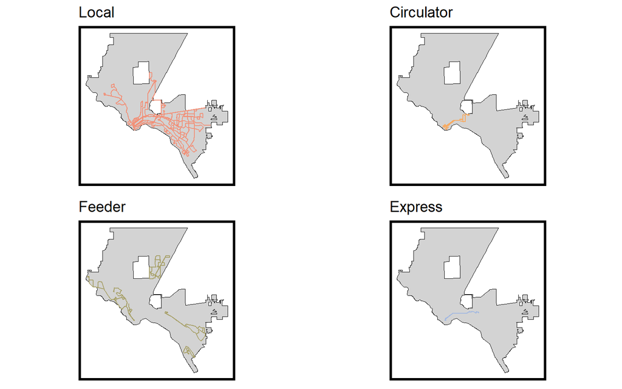

```r
classified <- bus_routes %>%
    mutate(
    type = case_when(
      ROUTE == 2 ~ "Local",
      ROUTE == 7 ~ "Local",
      ROUTE == 10 ~ "Local",
      ROUTE == 14 ~ "Local",
      ROUTE == 15 ~ "Local",
      ROUTE == 24 ~ "Local",
      ROUTE == 25 ~ "Local",
      ROUTE == 32 ~ "Local",
      ROUTE == 33 ~ "Local",
      ROUTE == 34 ~ "Local",
      ROUTE == 35 ~ "Local",
      ROUTE == 36 ~ "Local",
      ROUTE == 37 ~ "Local",
      ROUTE == 50 ~ "Local",
      ROUTE == 51 ~ "Local",
      ROUTE == 52 ~ "Local",
      ROUTE == 53 ~ "Local",
      ROUTE == 54 ~ "Local",
      ROUTE == 58 ~ "Local",
      ROUTE == 61 ~ "Local",
      ROUTE == 62 ~ "Local",
      ROUTE == 63 ~ "Local",
      ROUTE == 64 ~ "Local",
      ROUTE == 65 ~ "Local",
      ROUTE == 66 ~ "Local",
      ROUTE == 67 ~ "Local",
      ROUTE == 68 ~ "Local",
      ROUTE == 69 ~ "Local",
      ROUTE == 72 ~ "Local",
      ROUTE == 74 ~ "Local",
      ROUTE == 86 ~ "Local",
      ROUTE == 4 ~ "Circulator",
      ROUTE == 8 ~ "Circulator",
      ROUTE == 5 ~ "Express",
      ROUTE == 6 ~ "Express",
      ROUTE == 26 ~ "Express",
      ROUTE == 59 ~ "Express",
      ROUTE == 76 ~ "Express",
      ROUTE == 11 ~ "Feeder",
      ROUTE == 12 ~ "Feeder",
      ROUTE == 13 ~ "Feeder",
      ROUTE == 16 ~ "Feeder",
      ROUTE == 19 ~ "Feeder",
      ROUTE == 43 ~ "Feeder",
      ROUTE == 44 ~ "Feeder",
      ROUTE == 46 ~ "Feeder",
      ROUTE == 56 ~ "Feeder",
      ROUTE == 60 ~ "Feeder",
      ROUTE == 84 ~ "Feeder",
      ROUTE == 89 ~ "Feeder",
      ROUTE == 205 ~ "BRIO",
      ROUTE == 206 ~ "BRIO",
      ROUTE == 207 ~ "BRIO",
      ROUTE == 208 ~ "BRIO",
      ROUTE == 17 ~ "Other",
      ROUTE == 20 ~ "Other",
      ROUTE == 21 ~ "Circulator",
      ROUTE == 41 ~ "Other",
      ROUTE == 82 ~ "Other",
      ROUTE == 87 ~ "Other",
      ROUTE == 500 ~ "Streetcar"
    )
  )

classified <- na.omit(classified)

local <- classified[classified$type %in% "Local", ]
circulator <- classified[classified$type %in% "Circulator", ]
feeder <- classified[classified$type %in% "Feeder", ]
express <- classified[classified$type %in% "Express", ]

grid.arrange(ncol=2,
localMap <- ggplot()+
  geom_sf(data=el_paso, fill='lightgrey', color="black", size=20)+
  geom_sf(data=local, color=c(palette6[2]), size=2)+
  labs(title="Local")+
  mapTheme,
circulatorMap <- ggplot()+
  geom_sf(data=el_paso, fill='lightgrey', color="black", size=20)+
  geom_sf(data=circulator, color=c(palette6[3]), size=2)+
  labs(title="Circulator")+
  mapTheme,
feederMap <- ggplot()+
  geom_sf(data=el_paso, fill='lightgrey', color="black", size=20)+
  geom_sf(data=feeder, color=c(palette6[4]), size=2)+
  labs(title="Feeder")+
  mapTheme,
expressMap <- ggplot()+
  geom_sf(data=el_paso, fill='lightgrey', color="black", size=20)+
  geom_sf(data=express, color=c(palette6[5]), size=2)+
  labs(title="Express")+
  mapTheme
)
```

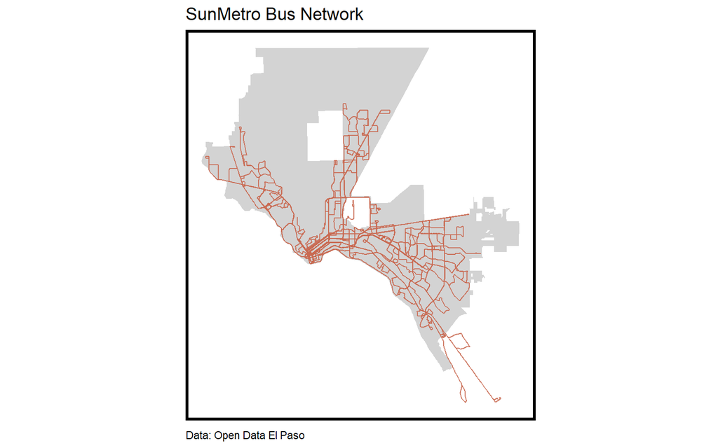

```r
ep_roads <- st_intersection(road_centerlines, el_paso)

ggplot()+
  geom_sf(data=el_paso,
          fill="lightgrey",
          color=NA)+
  geom_sf(data=bus_routes,
          alpha=0.9,
          color="#C96A52FF",
          size=1)+
  labs(title="SunMetro Bus Network",
       caption="Data: Open Data El Paso")+
  mapTheme
```

## Analyzing route ridership

Next, we looked at current route ridership. We aggregated the dataset to the route level and calculated the total ridership. As stated before, the BRIO bus rapid transit routes dominate in ridership, accounting for approximately 40% of total transit ridership. The three most popular routes are the 205, 206, and 207. The fourth BRIO line, opened in October 2022, still had higher ridership than almost half of other routes. While there are a handful of local ridership routes that have comparable ridership, the trend teeters out, and most local routes experience relatively low ridership. This can be attributed to a variety of factors: there are low demand in these areas.

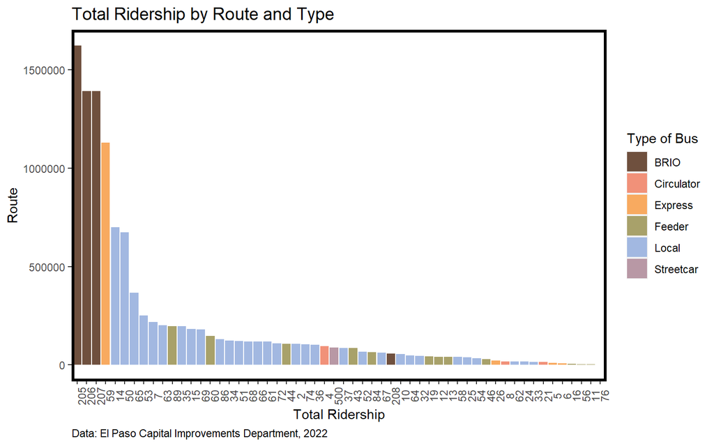

```r
RT_avg_sum_st <- st_drop_geometry(RT_avg_sum)

merged <- merge(transit_lines, RT_avg_sum_st, by.x = "route_short_name", by.y = "RT")

RT_avg_sum_st <- RT_avg_sum_st[order(-RT_avg_sum_st$total_ridership),]

ggplot(RT_avg_sum_st, aes(y = total_ridership, x = reorder(factor(RT), -total_ridership), fill = type)) +
  geom_bar(stat = "identity") +
  xlab("Total Ridership") +
  ylab("Route") +
  scale_fill_manual(values = palette7, name="Type of Bus", expand=c(0.2, 0)) +
  labs(title="Total Ridership by Route and Type",
       caption="Data: El Paso Capital Improvements Department, 2022")+
  plotTheme+
  theme(axis.text.x = element_text(angle=90))
```

## Ridership Scatterplot

As the scatter plot indicates, there is a strong correlation between average on-board and off-board frequency. This indicates that in bus transit trips, the average rider may exhibit round-trip behavior, boarding the bus at point A to travel to point B and then returning to point A without any intermediate stops.

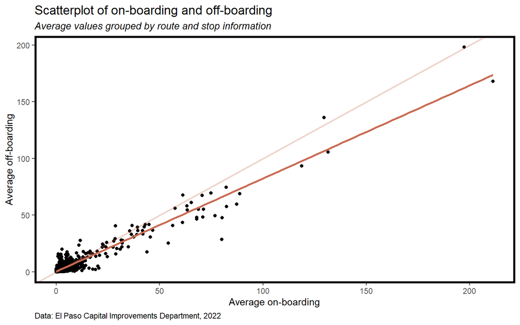

```r
RT_stop_avg_st <- st_drop_geometry(RT_stop_avg)

ggplot(RT_stop_avg_st, aes(x = avg_ons, y = avg_offs)) +
  geom_point() +
  labs(x = "Average on-boarding",
       y = "Average off-boarding",
       title = "Scatterplot of on-boarding and off-boarding",
       subtitle="Average values grouped by route and stop information",
       caption="Data: El Paso Capital Improvements Department, 2022")+
  geom_smooth(method = lm, se=FALSE, colour = "#C96A52FF", size=1, )+
  geom_abline(intercept=0, slope=1, color="#C96A52FF", alpha=0.3, size=1, style='dashed')+
  plotTheme
```

## Ridership by Census Tract

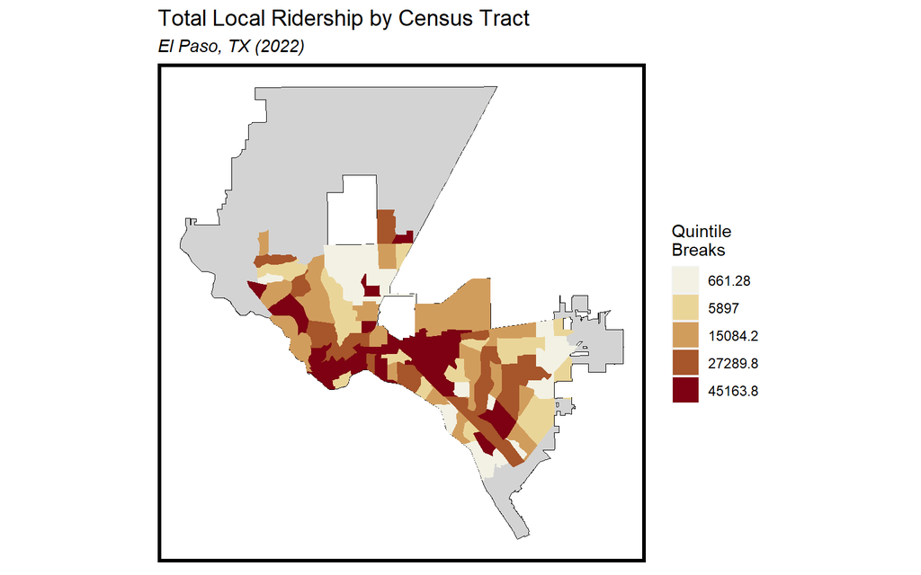

```r
acs.2020 <- get_acs(geography = "tract",
                  year = 2020,
                  variables = 'B01001_001E',
                  geometry = T,
                  state = "TX",
                  county = "El Paso",
                  output = "wide")
acs.2020 <- acs.2020 %>%
  st_transform(crs = 4269)

el_paso <- el_paso %>%
  st_transform(crs = 4269)

acs.2020_EP <- st_intersection(el_paso, acs.2020)

local_agg <- local1 %>%
  group_by(RT, TP, longitude, latitude) %>%
  summarize(total_ons = sum(Ons),
            total_offs = sum(Offs)) %>%
  mutate(total_ridership = (total_ons + total_offs)) %>%
  dplyr::select(-c("total_ons", "total_offs"))

local_agg <- local_agg %>%
  dplyr::select(c("geometry", "total_ridership")) %>%
  st_transform(crs=4269)

joined_data <- st_join(local_agg, acs.2020_EP, join = st_within)

agg_data <- joined_data %>%
  group_by(GEOID) %>%
  summarise(total_ridership = sum(total_ridership))

agg_data <- agg_data %>%
  st_drop_geometry()

agg_data2 <- left_join(agg_data, acs.2020_EP, by = "GEOID") %>%
  st_as_sf() %>%
  st_transform(crs=4269) %>%
  dplyr::select(c("total_ridership", "geometry"))

ggplot()+
  geom_sf(data = el_paso, fill="lightgrey", color="black", size=80)+
  geom_sf(data = agg_data2, aes(fill = q5(total_ridership)), color=NA)+
  scale_fill_manual(values = rev(palette5cont),
                     labels = (qBr(agg_data2, "total_ridership")),
                    name="Quintile\nBreaks") +
  labs(title="Total Local Ridership by Census Tract",
       subtitle="El Paso, TX (2022)")+
  mapTheme
```

# Feature Engineering

We are building a latent bus transit demand prediction model. Thus, we engineered a variety of features that we hypothesized were correlative to bus transit demand. We pulled our features primarily from five main sources, tabulated below.

```r
sources <- c(
  "American Community Survey (2019)",
  "National Walkability Index (2019)",
  "Longitudinal Employer-Household Dynamics",
  "Open Data El Paso",
  "Open Street Map"
)

descriptions <- c(
  "Provides demographic information to inform spatial distribution of population",
  "Offers measures of amenity and place-based accessibility at the census block level",
  "Provides employer/employee data to provide greater economic insight",
  "Offers built environment and land use characteristics data",
  "Measures distance information to various amenities"
)

table_ftrs <- list(
  Sources = sources,
  Description = descriptions
)

kable(table_ftrs, col.names = NULL) %>%
  add_header_above(c("Sources" = 1, "Description" = 1)) %>%
  kable_paper(full_width = FALSE)
```

Sources

Description

| American Community Survey (2019) |
| --- |
| National Walkability Index (2019) |
| Longitudinal Employer-Household Dynamics |
| Open Data El Paso |
| Open Street Map |

| Provides demographic information to inform spatial distribution of population |
| --- |
| Offers measures of amenity and place-based accessibility at the census block level |
| Provides employer/employee data to provide greater economic insight |
| Offers built environment and land use characteristics data |
| Measures distance information to various amenities |

## American Community Survey (2020)

We utilized the census API to gather a range of demographic information, socioeconomic status, household income and occupancy rates, education, and travel patterns, among other variables. This data will provide valuable insights into the equity and accessibility implications of our model, as marginalized populations often heavily rely on public transit but may face barriers in utilizing buses efficiently. We aimed to explore the spatial distribution of these demographics to identify any potential spatial relationships and understand their potential impact on bus transit demand. Below, we showcase some interesting maps depicting census features.

```r
censusvarsEP <- c(
  "B01001_001E", # ACS total Pop estimate
  "B01001I_001E", # Population - Hispanic or Latino
  "B02001_002E", # Population - White alone
  "B02001_003E", # Population - Black or African American alone
  "B02001_004E", # Population - American Indian and Alaska Native alone
  "B02001_005E", # Population - Asian alone
  "B02001_006E", # Population - Native Hawaiian and Other Pacific Islander alone
  "B02001_007E", # Population - Some other race alone
  "B02001_008E", # Population - Two or more races
  "B19013_001E", # Median household income in the past 12 months (in 2019 inflation-adjusted dollars)
  "B25001_001E", # Total housing units
  "B25002_002E", # Occupancy status - Occupied housing units
  "B25024_001E", # Gross rent as a percentage of household income in the past 12 months
  "B25044_001E", # Vehicles available
  "B28005_001E", # Means of transportation to work by age
  "B28010_001E", # Commuting time to work (in minutes)
  "B10052_002E", # Disability
  "B06009_002E", # Less than high school
  "B06009_003E", # High School
  "B06009_004E", # Associates or equivalent
  "B06009_005E", # Bachelors
  "B06009_006E" # Graduate or prof. degree
)

acs_ep <- get_acs(geography = "tract",
                  year = 2019,
                  variables = censusvarsEP,
                  geometry = T,
                  state = "TX",
                  county = "El Paso",
                  output = "wide")

#vec to not divide by sqkm
dontdiv <- c("GEOID","NAME","medHHInc","grossRentPerInc","commuteToWork","geometry","area_sqmile")

acs_ep <- acs_ep %>%
  rename(
    totalPop = B01001_001E,
    hlPop = B01001I_001E,
    whitePop = B02001_002E,
    blackPop = B02001_003E,
    aiPop = B02001_004E,
    asianPop = B02001_005E,
    nhPop = B02001_006E,
    otherRacePop = B02001_007E,
    twoPlusRacePop = B02001_008E,
    medHHInc = B19013_001E,
    totalHU = B25001_001E,
    occupiedHU = B25002_002E,
    grossRentPerInc = B25024_001E,
    transByAge = B28005_001E,
    commuteToWork = B28010_001E,
    lessThanHS = B06009_002E,
    highSchool = B06009_003E,
    associatesDeg = B06009_004E,
    bachelorDeg = B06009_005E,
    professionalDeg = B06009_006E,
    disability = B10052_002E) %>%
  mutate(area_sqmile = st_area(geometry)/2590000) %>%
  st_as_sf(crs = 4269) %>%
  mutate_at(vars(-dontdiv), funs(as.numeric(./area_sqmile)))

acs_ep <- acs_ep %>%
  mutate(
    whitePopPct = (whitePop/totalPop)*100,
    hlPopPct = (hlPop/totalPop)*100,
    asianPopPct = (asianPop/totalPop)*100,
    blackPopPct = (blackPop/totalPop)*100,
    occupiedHUPct = (occupiedHU/totalHU)*100,
    vacantHUPct = ((totalHU-occupiedHU)/totalHU)*100
  )

acs_ep <- acs_ep %>%
  dplyr::select(-c("B01001_001M", "B01001I_001M", "B02001_002M", "B02001_003M", "B02001_004M", "B02001_005M", "B02001_006M", "B02001_007M", "B02001_008M", "B19013_001M", "B25001_001M", "B25002_002M", "B25024_001M", "B25044_001M", "B28005_001M", "B28010_001M","B10052_002M", "B06009_002M", "B06009_003M", "B06009_004M", "B06009_005M", "B06009_006M"))

acs_ep <- na.omit(acs_ep)

st_crs(acs_ep) <- st_crs(el_paso)
acs_ep <- st_intersection(acs_ep, el_paso)
```

```r
censusvarsEP <- c(
  "B01001_001E", # ACS total Pop estimate
  "B01001I_001E", # Population - Hispanic or Latino
  "B02001_002E", # Population - White alone
  "B02001_003E", # Population - Black or African American alone
  "B02001_004E", # Population - American Indian and Alaska Native alone
  "B02001_005E", # Population - Asian alone
  "B02001_006E", # Population - Native Hawaiian and Other Pacific Islander alone
  "B02001_007E", # Population - Some other race alone
  "B02001_008E", # Population - Two or more races
  "B19013_001E", # Median household income in the past 12 months (in 2019 inflation-adjusted dollars)
  "B25001_001E", # Total housing units
  "B25002_002E", # Occupancy status - Occupied housing units
  "B25024_001E", # Gross rent as a percentage of household income in the past 12 months
  "B25044_001E", # Vehicles available
  "B28005_001E", # Means of transportation to work by age
  "B28010_001E", # Commuting time to work (in minutes)
  "B10052_002E", # Disability
  "B06009_002E", # Less than high school
  "B06009_003E", # High School
  "B06009_004E", # Associates or equivalent
  "B06009_005E", # Bachelors
  "B06009_006E" # Graduate or prof. degree
)

ep <- get_acs(geography = "tract",
              year = 2020,
              variables = censusvarsEP,
              geometry = T,
              state = "TX",
              county = "El Paso",
              output = "wide")

ep <- ep %>%
  rename(
    totalPop = B01001_001E,
    hlPop = B01001I_001E,
    whitePop = B02001_002E,
    blackPop = B02001_003E,
    aiPop = B02001_004E,
    asianPop = B02001_005E,
    nhPop = B02001_006E,
    otherRacePop = B02001_007E,
    twoPlusRacePop = B02001_008E,
    medHHInc = B19013_001E,
    totalHU = B25001_001E,
    occupiedHU = B25002_002E,
    grossRentPerInc = B25024_001E,
    transByAge = B28005_001E,
    commuteToWork = B28010_001E,
    lessThanHS = B06009_002E,
    highSchool = B06009_003E,
    associatesDeg = B06009_004E,
    bachelorDeg = B06009_005E,
    professionalDeg = B06009_006E,
    disability = B10052_002E)

ep <- ep %>%
  mutate(
    whitePopPct = (whitePop/totalPop)*100,
    hlPopPct = (hlPop/totalPop)*100,
    asianPopPct = (asianPop/totalPop)*100,
    blackPopPct = (blackPop/totalPop)*100,
    occupiedHUPct = (occupiedHU/totalHU)*100,
    vacantHUPct = ((totalHU-occupiedHU)/totalHU)*100
  )

st_crs(ep) <- st_crs(el_paso)

ep <- st_intersection(ep, el_paso)
```

### Racial Distribution in El Paso

Four maps of the White, Hispanic/Latino, Black, and Asian populations are below. It appears that there is racial segregation, as census tracts with the greatest density of Black residents seem to have decreased amount of White and Latino residents. There also is a strip along the Rio Grande in the southeastern part of the city where there is an incredibly high density of Hispanic/Latino residents. A high density of Asian residents seem to live just northwest of downtown.

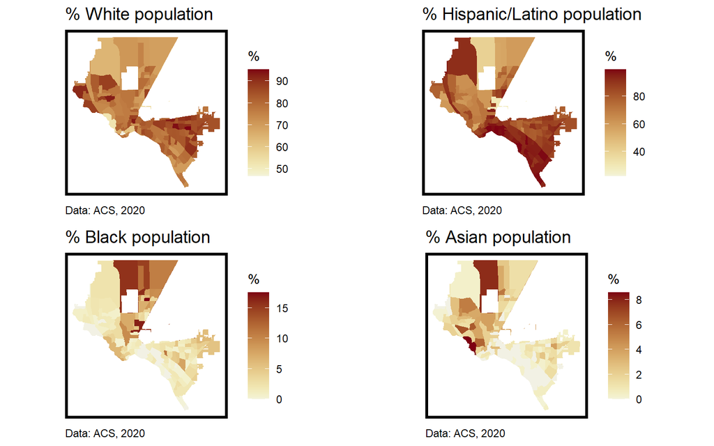

```r
grid.arrange(ncol=2,
             ggplot()+
               geom_sf(data=acs_ep, aes(fill=whitePopPct), color=NA)+
               scale_fill_paletteer_c("grDevices::Red-Yellow", -1, name="%")+
               labs(title="% White population",
                    caption="Data: ACS, 2020")+
               mapTheme,
             ggplot()+
               geom_sf(data=acs_ep, aes(fill=hlPopPct), color=NA)+
               scale_fill_paletteer_c("grDevices::Red-Yellow", -1, name="%")+
               labs(title="% Hispanic/Latino population",
                    caption="Data: ACS, 2020")+
               mapTheme,
             ggplot()+
               geom_sf(data=acs_ep, aes(fill=blackPopPct), color=NA)+
               scale_fill_paletteer_c("grDevices::Red-Yellow", -1, name="%")+
               labs(title="% Black population",
                    caption="Data: ACS, 2020")+
               mapTheme,
             ggplot()+
               geom_sf(data=acs_ep, aes(fill=asianPopPct), color=NA)+
               scale_fill_paletteer_c("grDevices::Red-Yellow", -1, name="%")+
               labs(title="% Asian population",
                    caption="Data: ACS, 2020")+
               mapTheme
)
```

### Household Vacancy

Vacant households may contribute to ridership demand; if units are unoccupied, there is a decreased density of residents and thus less people who may need to utilize buses. There seems to be a relatively random spatial pattern on percentage of vacant housing units. It appears more densified areas such as downtown see higher rates of vacancy.

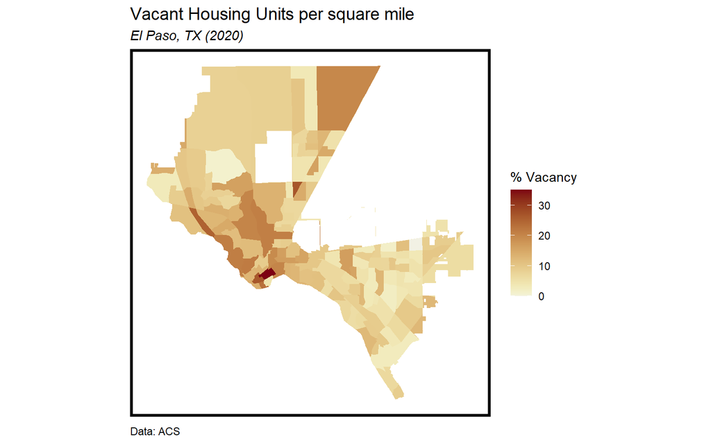

```r
ggplot()+
  geom_sf(data=acs_ep, aes(fill=vacantHUPct), color=NA)+
  scale_fill_paletteer_c("grDevices::Red-Yellow", -1, name="% Vacancy")+
  labs(title="Vacant Housing Units per square mile",
       subtitle="El Paso, TX (2020)",
       caption="Data: ACS")+
  mapTheme
```

### Median Household Income

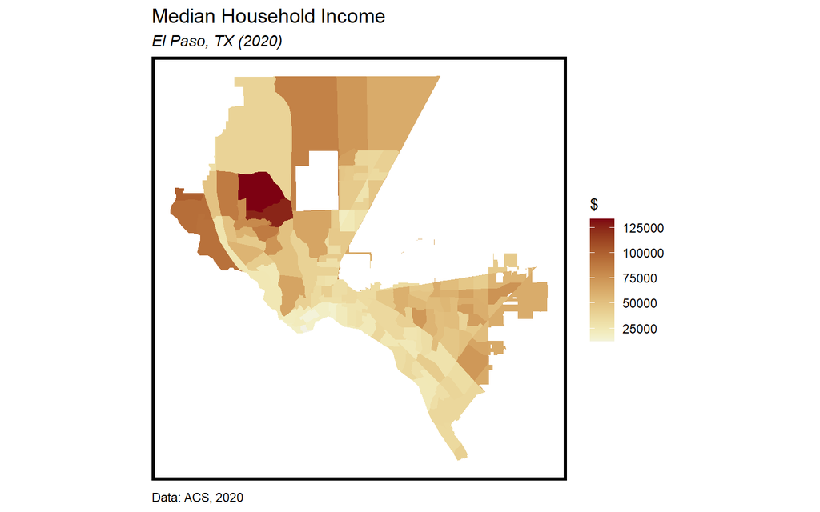

```r
ggplot()+
  geom_sf(data=acs_ep, aes(fill=medHHInc), color=NA)+
  scale_fill_paletteer_c("grDevices::Red-Yellow", -1, name="$")+
  labs(title="Median Household Income",
       subtitle="El Paso, TX (2020)",
       caption="Data: ACS, 2020")+
  mapTheme
```

## National Walkability Index (2019)

A major assumption of our model is that land use patterns and urban design play a huge role in people’s accessibility and desire to use transit, or their dependency on specific modes of transportation given inaccessibility of other modes. The National Walkability Index is a geographic resource that scores every block group in the U.S. on its relative walkability. A variety of factors explain walkability, including sidewalk availability, infrastructural assessment, street connectivity, amenity proximity, and urban form conducive to walkable neighborhoods.

From the Environmental Protection Agency, we derived the National Walkability Index (NWI) scores for 2019. This included a variety of indicators, including vehicle ownership, density of employment, jobs, and households, intersection and transit stop density, and regional and destination accessibility.

```r
nwi <- read_csv(paste(data_folder, "/nwi2019.csv", sep = '')) %>%
  dplyr::filter(CBSA_Name == "El Paso, TX") %>%
  dplyr::select(c("OBJECTID",
                  "GEOID10",
                  "TRACTCE",
                  "BLKGRPCE",
                  "TotPop",
                  "CountHU", # number of housing units
                  "P_WrkAge", # percent working age pop. (18-64)
                  "HH", # households
                  "Pct_AO0", # % of HH owning 0 vehicles
                  "Pct_AO1", # % of HH owning 1 vehicle
                  "Pct_AO2p", # % of HH owning 2+ vehicles
                  "R_PCTLOWWAGE", # % of low wage workers
                  "D1C", # employment density
                  "D2R_JOBPOP", # jobs to population balance
                  "D2B_E8MIXA", # employment mix
                  "D2A_EPHHM", # employment + household mix
                  "D3B", # intersection density
                  "D4A", # distance from population-weighted centroid to nearest transit stop
                  "D5AR", # regional accessibility for access to jobs
                  "D5BR", # destination accessibility via transit
  ))

nwi$GEOID <- paste0(substr(nwi$GEOID10, 1, 5), "0", sprintf("%05d", nwi$TRACTCE), nwi$BLKGRPCE)

blocks <-read_sf(paste(data_folder, "/tl_2019_48_bg.shp", sep = '')) %>%
  dplyr::filter(COUNTYFP == 141) %>%
  dplyr::select(-c("STATEFP", "COUNTYFP", "TRACTCE", "BLKGRPCE", "NAMELSAD", "MTFCC", "FUNCSTAT", "ALAND", "AWATER", "INTPTLAT", "INTPTLON"))

nwi_bg <- left_join(nwi, blocks, by = "GEOID")

nwi_bg <- st_as_sf(nwi_bg)

nwi_bg <- nwi_bg %>%
  rename(
    totalPop = TotPop,
    housingUnits = CountHU,
    pctWorkingAge = P_WrkAge,
    housingUnits = CountHU,
    pct0Car = Pct_AO0,
    pct1Car = Pct_AO1,
    pct2Car = Pct_AO2p,
    pctLowWage = R_PCTLOWWAGE,
    employmentDensity = D1C,
    jobsPopBalance = D2R_JOBPOP,
    employmentMix = D2B_E8MIXA,
    employmentHHMix = D2A_EPHHM,
    intersectionDensity = D3B,
    nearestTransit = D4A,
    jobAccessibility = D5AR,
    destinationAccessibility = D5BR
  )

nwi_bg %>%
  dplyr::select(-c("OBJECTID",
                   "GEOID10",
                   "TRACTCE",
                   "BLKGRPCE",))

st_crs(nwi_bg) <- st_crs(el_paso)
nwi_bg <- st_intersection(nwi_bg, el_paso)
nwi_bg_st <- st_drop_geometry(nwi_bg)

nwi_bg_NA <- nwi_bg %>%
  dplyr::filter(nearestTransit != -99999.00)

nwi_bg_st_NA <- nwi_bg_st %>%
  dplyr::filter(nearestTransit != -99999.00)
```

### Nearest Transit Accessibility

The nearest transit accessibility score is calculated as the distance (in meters) from the population-weighted centroid. This involves aggregating all bus stops within each census block into the block, determining the centroid of the block based on population distribution, and calculating the distance between the centroid and its nearest stop. This method takes into account accessibility for the greatest number of people within the block, which is its strength. However, there may be issues with the choice of areal unit.

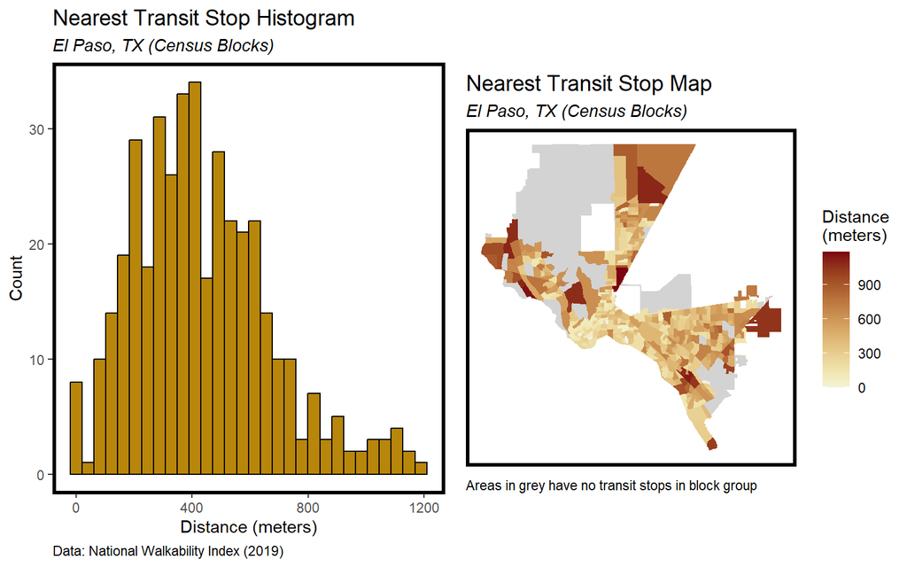

```r
grid.arrange(ncol=2,
ggplot(nwi_bg_st_NA, aes(x = nearestTransit)) +
  geom_histogram(color = "black", fill = "#B8860B") +
  labs(title = "Nearest Transit Stop Histogram",
       subtitle = "El Paso, TX (Census Blocks)",
       x = "Distance (meters)",
       y = "Count",
       caption = "Data: National Walkability Index (2019)")+
  plotTheme,
ggplot()+
  geom_sf(data=el_paso, fill="lightgrey", color=NA)+
  geom_sf(data=nwi_bg_NA, aes(fill=nearestTransit), color=NA)+
  scale_fill_paletteer_c("grDevices::Red-Yellow", -1, name="Distance\n(meters)")+
  labs(title="Nearest Transit Stop Map",
       subtitle="El Paso, TX (Census Blocks)",
       caption="Areas in grey have no transit stops in block group")+
  mapTheme
)
```

### Destination Accessibility

The destination accessibility metric is measured as jobs within 45-minute transit commute, accounting for factors such as distance decay (accessibility of jobs may decrease with increasing distance from a particular location) and time it takes to walk to a transit stop. General Transit Feed Specification (GTFS) data was used in tandem to calculate this metric.

We can see where there is increased density of jobs (e.g. downtown, UTEP), the metric is higher.

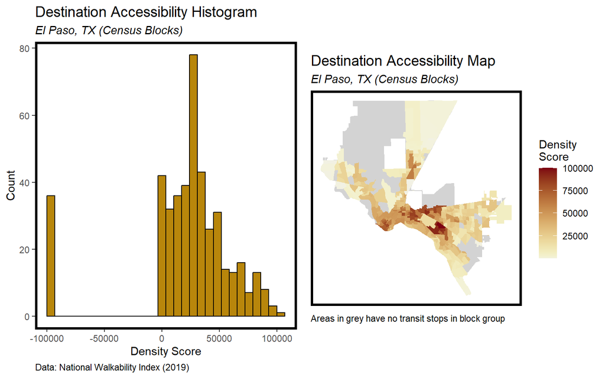

```r
grid.arrange(ncol=2,
ggplot(nwi_bg_st, aes(x = destinationAccessibility)) +
  geom_histogram(color = "black", fill = "#B8860B") +
  labs(title = "Destination Accessibility Histogram",
       subtitle = "El Paso, TX (Census Blocks)",
       x = "Density Score",
       y = "Count",
       caption = "Data: National Walkability Index (2019)")+
  plotTheme,
ggplot()+
  geom_sf(data=el_paso, fill="lightgrey", color=NA)+
  geom_sf(data=nwi_bg_NA, aes(fill=destinationAccessibility), color=NA)+
  scale_fill_paletteer_c("grDevices::Red-Yellow", -1, name="Density\nScore")+
  labs(title="Destination Accessibility Map",
       subtitle="El Paso, TX (Census Blocks)",
       caption="Areas in grey have no transit stops in block group")+
  mapTheme
)
```

### Jobs to Population Balance

This metric is a measurement that captures the number of jobs relative to the population in a given area, providing insights into employment opportunities and population dynamics of the census block and the greater region.

[figure not shown]

```r
grid.arrange(ncol=2,
ggplot(nwi_bg_st, aes(x = jobsPopBalance)) +
  geom_histogram(color = "black", fill = "#B8860B") +
  labs(title = "Intersection Density Histogram",
       subtitle = "El Paso, TX (Census Blocks)",
       x = "Score",
       y = "Count")+
  plotTheme,
ggplot()+
  geom_sf(data=nwi_bg, aes(fill=jobsPopBalance), color=NA)+
  scale_fill_paletteer_c("grDevices::Red-Yellow", -1, name="Density\nScore")+
  labs(title="Intersection Density Map",
       subtitle="El Paso, TX (Census Blocks)")+
  mapTheme
)
```

### Intersection Density (D3B)

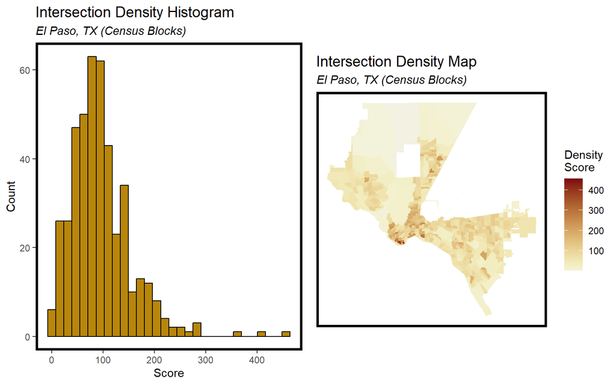

```r
grid.arrange(ncol=2,
ggplot(nwi_bg_st, aes(x = intersectionDensity)) +
  geom_histogram(color = "black", fill = "#B8860B") +
  labs(title = "Intersection Density Histogram",
       subtitle = "El Paso, TX (Census Blocks)",
       x = "Score",
       y = "Count")+
  plotTheme,
ggplot()+
  geom_sf(data=nwi_bg, aes(fill=intersectionDensity), color=NA)+
  scale_fill_paletteer_c("grDevices::Red-Yellow", -1, name="Density\nScore")+
  labs(title="Intersection Density Map",
       subtitle="El Paso, TX (Census Blocks)")+
  mapTheme
)
```

## Longitudinal Employment-Household Data (LEHD)

Longitudinal Employment-Household Data (LEHD) is a dataset that provides detailed information on employment and earnings in the United States. It is produced by the U.S. Census Bureau in partnership with state labor market agencies to help create a comprehensive, state-level picture of employment and earning patterns over time.

We accessed LEHD for the year 2019 from the **lehdr** package for the state of Texas at the census tract level, and aggregated features related to number of jobs; age, race, gender, educational level of workers; income of workers; and job sector distribution. We decided LEHD would be a useful mechanism to bake equity and accessibility features into our model. Considering different job sectors and worker demographics may have increased demand for transit (e.g., tracts with higher low wage workers, lower-skilled labor, etc.), it will likely increase the predictive power of transit ridership.

```r
#https://lehd.ces.census.gov/data/lodes/LODES7/LODESTechDoc7.5.pdf

#get lhodes work place data
tx_work <- grab_lodes(state = "tx",
                      year = 2019,
                      lodes_type = "wac",
                      job_type = "JT01",
                      segment = "S000",
                      state_part = "main",
                      agg_geo = "tract") %>%
  rename(total_jobs = C000,
         age_29_or_younger = CA01,
         age_30_to_54 = CA02,
         age_55_or_older = CA03,
         monthly_income_1250_or_less = CE01,
         monthly_income_1251_to_3333 = CE02,
         monthly_income_3334_or_more = CE03,
         agriculture = CNS01, # agriculture, forestry, fishing, hunting / NAICS11
         mining = CNS02, # mining, oil/gas extraction / MAICS21
         utilities = CNS03, # utilities / NAICS22
         construction = CNS04, # construction / NAICS23
         manufacturing = CNS05, # manufacturing /NAICS31 and NAICS33
         wholesaleTrade = CNS06, # wholesale trade / NAICS42
         retailTrade = CNS07, # retail trade / 44/46
         transportationWarehousing = CNS08, # transportation and warehousing / 48, 49
         informationTech = CNS09, # information /51
         financeInsurance = CNS10, # finance and insurance /52
         realEstate = CNS11, # real estate /53
         techServices = CNS12, # professional, scientific, and tech services /54
         management = CNS13, # management (enterprise) /55
         wasteRemediation = CNS14, # waste / remediation /56
         educational = CNS15, # education /61
         healthcareSocial = CNS16, # healthcare/social services /62
         artsEntertainmentRec = CNS17, # arts/entertainment/rec /71
         foodServices = CNS18, # food services /72
         otherJobs = CNS19, # other /81
         publicAdmin = CNS20, # public admin /92
         white_work = CR01,
         black_work = CR02,
         native_american_work = CR03,
         asian_work = CR04,
         pacific_work = CR05,
         mixed_race_work = CR07,
         not_hispanic_work = CT01,
         hispanic_work = CT02,
         male_work = CS01,
         female_work = CS02,
         underHS_work = CD01,
         HS_work = CD02,
         associate_work = CD03,
         bachProfessional_work = CD04)

tx_work <- tx_work %>%
  mutate(
    age29youngerPct = (age_29_or_younger/total_jobs),
    age30to54Pct = (age_29_or_younger/total_jobs),
    age55olderPct = (age_55_or_older/total_jobs),
    income1250LessPct = (monthly_income_1250_or_less/total_jobs),
    income1251to3333Pct = (monthly_income_1251_to_3333/total_jobs),
    income3333OverPct = (monthly_income_3334_or_more/total_jobs),
    agriculturePct = (agriculture/total_jobs),
    miningPct = (mining/total_jobs),
    utilitiesPct = (utilities/total_jobs),
    constructionPct = (construction/total_jobs),
    manufacturingPct = (manufacturing/total_jobs),
    wholesaleTradePct = (wholesaleTrade/total_jobs),
    retailTradePct = (retailTrade/total_jobs),
    transportationWarehousingPct = (transportationWarehousing/total_jobs),
    informationTechPct = (informationTech/total_jobs),
    financeInsurancePct = (financeInsurance/total_jobs),
    realEstatePct = (realEstate/total_jobs),
    techServicesPct = (techServices/total_jobs),
    managementPct = (management/total_jobs),
    wasteRemediationPct = (wasteRemediation/total_jobs),
    educationalPct = (educational/total_jobs),
    healthcareSocialPct = (healthcareSocial/total_jobs),
    artsEntertainmentRecPct = (artsEntertainmentRec/total_jobs),
    foodServicesPct = (foodServices/total_jobs),
    otherJobsPct = (otherJobs/total_jobs),
    publicAdminPct = (publicAdmin/total_jobs),
    whiteWorkPct = (white_work/total_jobs),
    blackWorkPct = (black_work/total_jobs),
    nativeAmericanWorkPct = (native_american_work/total_jobs),
    asianWorkPct = (asian_work/total_jobs),
    pacificWorkPct = (pacific_work/total_jobs),
    mixedRaceWorkPct = (mixed_race_work/total_jobs),
    notHispanicWorkPct = (not_hispanic_work/total_jobs),
    hispanicWorkPct = (hispanic_work/total_jobs),
    underHSWorkPct = (underHS_work/total_jobs),
    hsWorkPct = (HS_work/total_jobs),
    associateWorkPct = (associate_work/total_jobs),
    bachProfessionalWorkPct = (bachProfessional_work/total_jobs),
    maleWorkPct = (male_work/total_jobs),
    femaleWorkPct = (female_work/total_jobs)
  )

ep_work_census <- left_join(acs_ep, tx_work, by=c('GEOID' = 'w_tract'))

#ep_work_census <- ep_work_census %>%
 # select(-starts_with("CF"))

ep_work_census_st <- ep_work_census %>%
  st_drop_geometry()
```

### Income Distribution of Jobs - Monthly Income

We calculated the percentage of each monthly income bracket of the census tracts - which in LEHD are divided as making under $1250 per month, between $1251 and $3333 per month, or over $3334 per month.

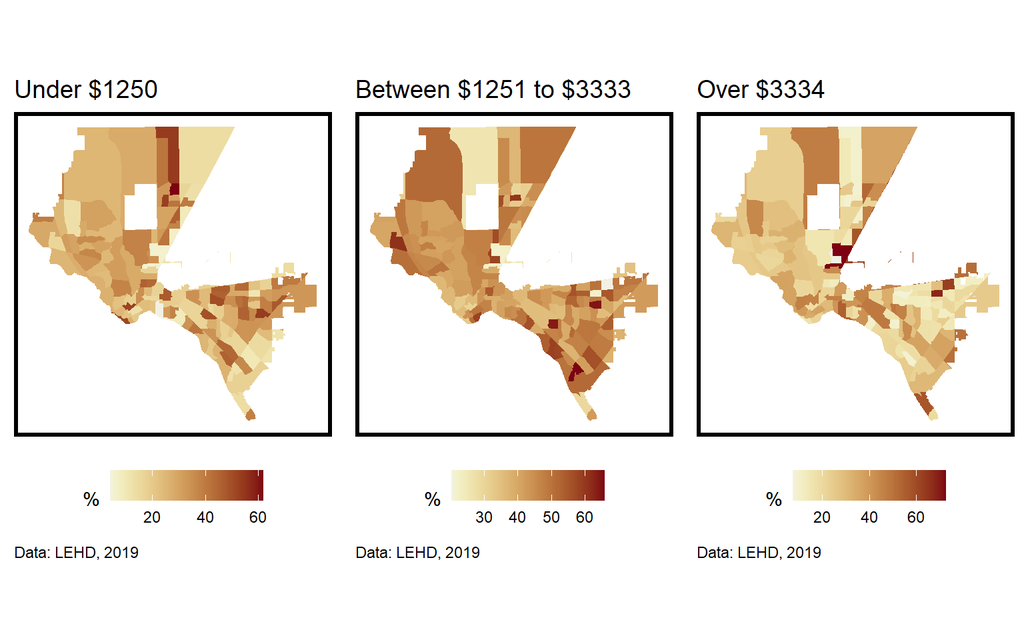

```r
grid.arrange(ncol=3,
ggplot()+
  geom_sf(data=ep_work_census, aes(fill=income1250LessPct*100), color=NA)+
  scale_fill_paletteer_c("grDevices::Red-Yellow", -1, name="%")+
  labs(title="Under $1250",
       caption="Data: LEHD, 2019")+
  mapTheme+
  theme(legend.position = 'bottom'),
ggplot()+
  geom_sf(data=ep_work_census, aes(fill=income1251to3333Pct*100), color=NA)+
  scale_fill_paletteer_c("grDevices::Red-Yellow", -1, name="%")+
  labs(title="Between $1251 to $3333",
       caption="Data: LEHD, 2019")+
  mapTheme+
  theme(legend.position = 'bottom'),
ggplot()+
  geom_sf(data=ep_work_census, aes(fill=income3333OverPct*100), color=NA)+
  scale_fill_paletteer_c("grDevices::Red-Yellow", -1, name="%")+
  labs(title="Over $3334",
       caption="Data: LEHD, 2019")+
  mapTheme+
  theme(legend.position = 'bottom')
)
```

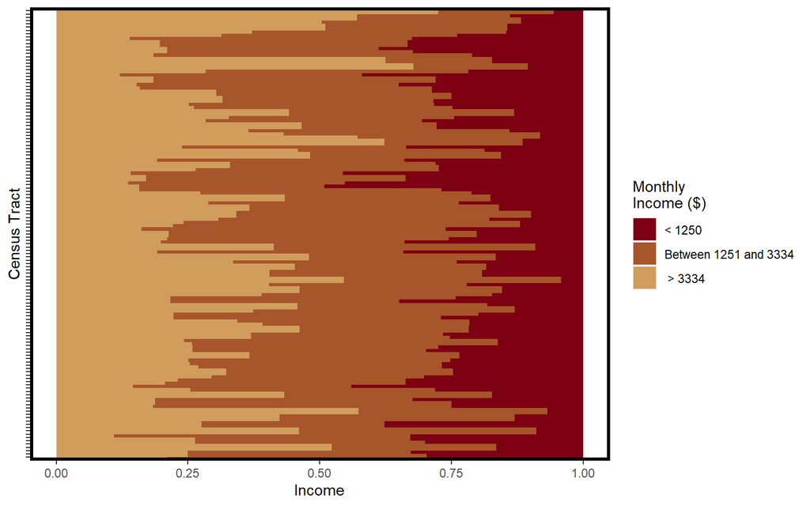

```r
epworkincome <- ep_work_census_st[, c("GEOID", "income1250LessPct", "income1251to3333Pct", "income3333OverPct")]

epworktidy <- epworkincome %>%
  gather(key = "IncomeLevel", value = "Income", -GEOID)

ggplot(epworktidy, aes(x = Income, y = GEOID, fill = IncomeLevel)) +
  geom_bar(stat = "identity", position = "stack", width=2) +
  scale_fill_manual(values=c(palette5cont[1:3]),
                    labels=c("< 1250", "Between 1251 and 3334", " > 3334"))+
  labs(y = "Census Tract", x = "Income", fill = "Monthly \nIncome ($)") +
  plotTheme+
  theme(axis.text.y = element_blank())
```

## Open Data El Paso

Open Data El Paso is the city’s open-source data platform. We pulled several demographic and built environment features to engineer into our model that explain the impacts of transit demand.

### Schools

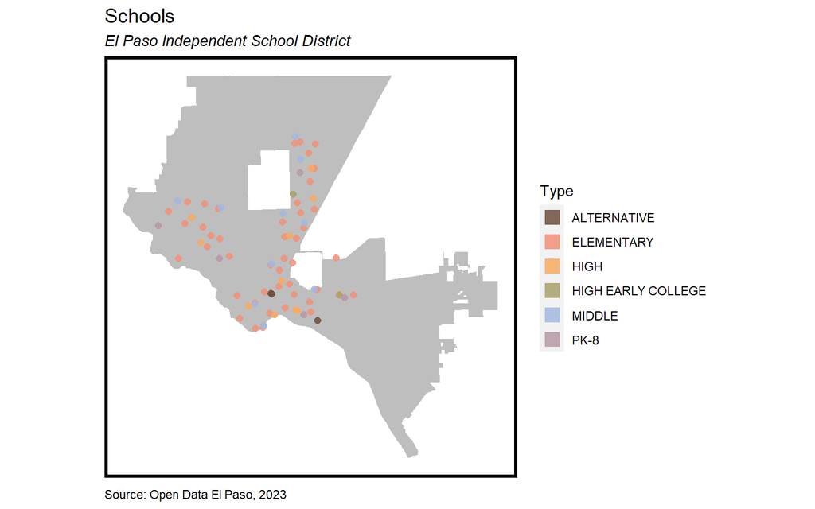

```r
schools <- schools %>%
  dplyr::filter(DISTRICT == "EL PASO") %>%
  dplyr::filter(TYPE_ != "ADMIN") %>%
  dplyr::filter(TYPE_ != "FACILITIES")

ggplot() +
  geom_sf(data = el_paso, fill = "grey", color = NA) +
  geom_sf(data = schools, aes(color = TYPE_), size = 2, alpha=0.85) +
  scale_color_manual(values = palette6, name = "Type") +
  guides(color = guide_legend(override.aes = list(shape = 22, size = 5, fill=palette6))) +
  labs(title="Schools",
       subtitle="El Paso Independent School District",
       caption="Source: Open Data El Paso, 2023")+
  mapTheme
```

### Parks

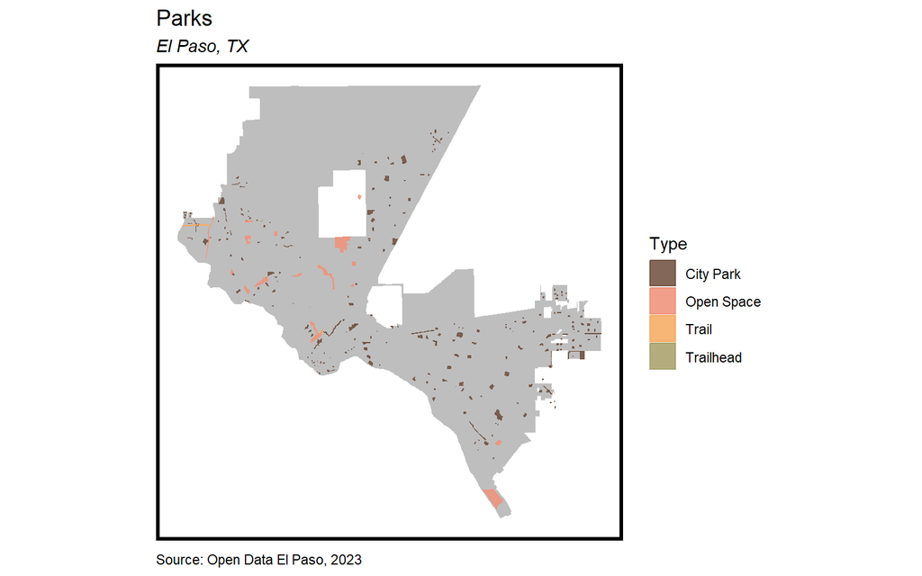

```r
parks <- parks %>%
  dplyr::filter(CATEGORY %in% c("City Park", "Open Space", "Trail", "Trailhead"))

ggplot() +
  geom_sf(data = el_paso, fill = "grey", color = NA) +
  geom_sf(data = parks, aes(fill = CATEGORY, color = CATEGORY), size = 2, alpha=0.85) +
  scale_fill_manual(values = palette6[1:4], name = "Type") +
  scale_color_manual(values = palette6[1:4], name = "Type") +
  guides(color = guide_legend(override.aes = list(shape = 22, size = 5, fill=palette6[1:4], color=palette6[1:4]))) +
  labs(title="Parks",
       subtitle="El Paso, TX",
       caption="Source: Open Data El Paso, 2023")+
  mapTheme
```

### Road Infrastructure

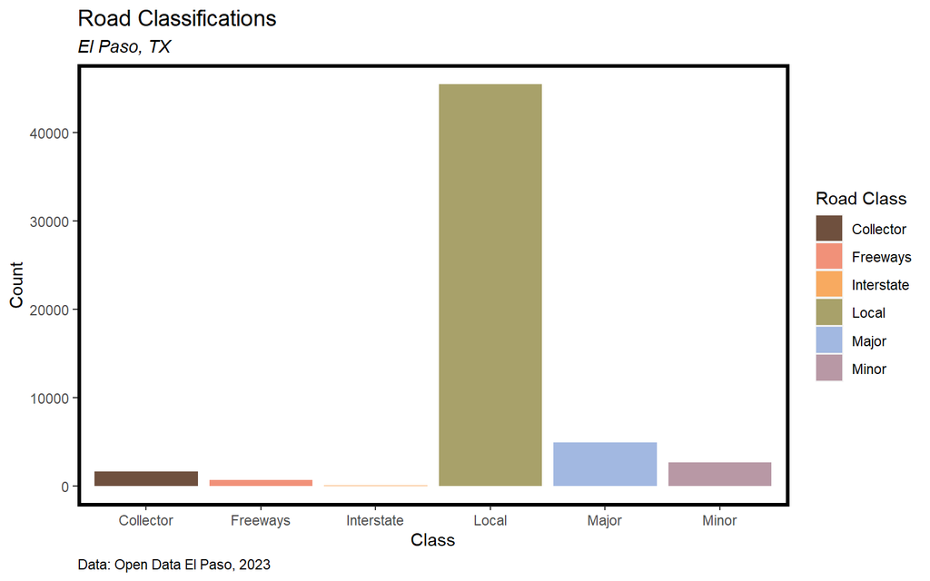

```r
road_class <- c(
  "LOCAL" = "Local",
  "MINOR" = "Minor",
  "FREEWAY" = "Freeways",
  "MAJOR" = "Major",
  "COLLECTOR" = "Collector",
  "INTERSTATE" = "Interstate",
  "LOCAL\r\n" = "Local",
  "LOCAL\r\n\r\n" = "Local",
  "LOCAL\r\n\r\n\r\n" = "Local",
  "LOCAL\r\n\r\n\r\n\r\n" = "Local"
)

roads$CLASS <- road_class[roads$CLASS]

roads <- roads %>%
  filter(!is.na(CLASS))

roads_sf <- st_as_sf(roads, coords = NULL)

class_count <- table(roads_sf$CLASS)

class_count_df <- data.frame(CLASS = names(class_count), Count = as.vector(class_count))

ggplot(class_count_df, aes(x = CLASS, y = Count, fill = CLASS)) +
  geom_col() +
  scale_fill_manual(values=c(palette6),
                    name='Road Class')+
  labs(title = "Road Classifications",
       subtitle = "El Paso, TX",
       caption = "Data: Open Data El Paso, 2023",
       x = "Class",
       y = "Count") +
  plotTheme
```

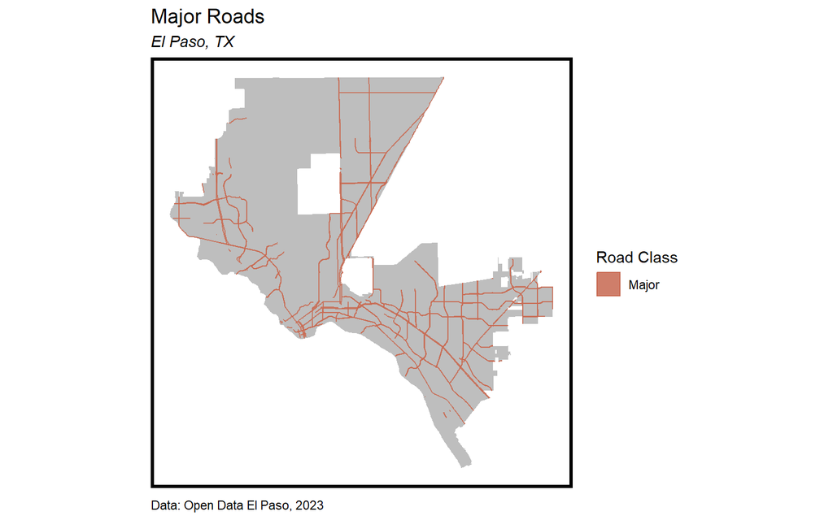

```r
major <- roads %>%
  dplyr::filter(CLASS == "Major") %>%
  st_transform(crs=4269)

majorEP <- st_intersection(el_paso, major)

ggplot()+
  geom_sf(data = el_paso, fill = "grey", color = NA) +
  geom_sf(data = majorEP, aes(fill=CLASS, color=CLASS), size = 4, alpha=0.85) +
  scale_fill_manual(values=palette1, name='Road Class')+
  scale_color_manual(values=palette1, name='Road Class')+
  labs(title="Major Roads",
       subtitle="El Paso, TX",
       caption="Data: Open Data El Paso, 2023")+
  mapTheme
```

## Open Street Map

One thing to note about OSM is that since it is a volunteer-based platform, it is not guaranteed every feature that matches each value may yet be aggregated into Open Street Map; however, we included all of these features given there seemed to be ample amount of points for each that still explained the spatial distribution of features in El Paso.

```r
# Hospital
hospital <- opq(bbox = 'El Paso, Texas') %>%
  add_osm_feature(key = 'amenity',
                  value = 'hospital') %>%
  osmdata_sf()

hospital_points <- hospital$osm_points

hospital_df <- as.data.frame(hospital_points) %>%
  st_as_sf() %>%
  st_transform(crs=4269)

hospital_points <- st_intersection(el_paso, hospital_df) %>%
  dplyr::select(c("geometry")) %>%
  mutate(type = "hospital")

# Clinic
clinic <- opq(bbox = 'El Paso, Texas') %>%
  add_osm_feature(key = 'amenity',
                  value = 'clinic') %>%
  osmdata_sf()

clinic_points <- clinic$osm_points

clinic_df <- as.data.frame(clinic_points) %>%
  st_as_sf() %>%
  st_transform(crs=4269)

clinic_points <- st_intersection(el_paso, clinic_df) %>%
  dplyr::select(c("geometry")) %>%
  mutate(type = "clinic")

# Pharmacy
pharmacy <- opq(bbox = 'El Paso, Texas') %>%
  add_osm_feature(key = 'amenity',
                  value = 'pharmacy') %>%
  osmdata_sf()

pharmacy_points <- pharmacy$osm_points

pharmacy_df <- as.data.frame(pharmacy_points) %>%
  st_as_sf() %>%
  st_transform(crs=4269)

pharmacy_points <- st_intersection(el_paso, pharmacy_df) %>%
  dplyr::select(c("geometry")) %>%
  mutate(type = "pharmacy")

# Restaurant
restaurant <- opq(bbox = 'El Paso, Texas') %>%
  add_osm_feature(key = 'amenity',
                  value = 'restaurant') %>%
  osmdata_sf()

restaurant_points <- restaurant$osm_points

restaurant_df <- as.data.frame(restaurant_points) %>%
  st_as_sf() %>%
  st_transform(crs=4269)

restaurant_points <- st_intersection(el_paso, restaurant_df) %>%
  dplyr::select(c("geometry")) %>%
  mutate(type = "restaurant")

# Cafe
cafe <- opq(bbox = 'El Paso, Texas') %>%
  add_osm_feature(key = 'amenity',
                  value = 'cafe') %>%
  osmdata_sf()

cafe_points <- cafe$osm_points

cafe_df <- as.data.frame(cafe_points) %>%
  st_as_sf() %>%
  st_transform(crs=4269)

cafe_points <- st_intersection(el_paso, cafe_df) %>%
  dplyr::select(c("geometry")) %>%
  mutate(type = "cafe")

# Bars
bar <- opq(bbox = 'El Paso, Texas') %>%
  add_osm_feature(key = 'amenity',
                  value = 'bar') %>%
  osmdata_sf()

bar_points <- bar$osm_points

bar_df <- as.data.frame(bar_points) %>%
  st_as_sf() %>%
  st_transform(crs=4269)

bar_points <- st_intersection(el_paso, bar_df) %>%
  dplyr::select(c("geometry")) %>%
  mutate(type = "bar")

# Places of Worship
worship <- opq(bbox = 'El Paso, Texas') %>%
  add_osm_feature(key = 'amenity',
                  value = 'place_of_worship') %>%
  osmdata_sf()

worship_points <- worship$osm_points

worship_df <- as.data.frame(worship_points) %>%
  st_as_sf() %>%
  st_transform(crs=4269)

worship_points <- st_intersection(el_paso, worship_df) %>%
  dplyr::select(c("geometry")) %>%
  mutate(type = "worship")

# Cinema
cinema <- opq(bbox = 'El Paso, Texas') %>%
  add_osm_feature(key = 'amenity',
                  value = 'cinema') %>%
  osmdata_sf()

cinema_points <- cinema$osm_points

cinema_df <- as.data.frame(cinema_points) %>%
  st_as_sf() %>%
  st_transform(crs=4269)

cinema_points <- st_intersection(el_paso, cinema_df) %>%
  dplyr::select(c("geometry")) %>%
  mutate(type = "cinema")

# Theaters
theatre <- opq(bbox = 'El Paso, Texas') %>%
  add_osm_feature(key = 'amenity',
                  value = 'theatre') %>%
  osmdata_sf()

theatre_points <- theatre$osm_points

theatre_df <- as.data.frame(theatre_points) %>%
  st_as_sf() %>%
  st_transform(crs=4269)

theatre_points <- st_intersection(el_paso, theatre_df) %>%
  dplyr::select(c("geometry")) %>%
  mutate(type = "restaurant")

# Department Stores
department <- opq(bbox = 'El Paso, Texas') %>%
  add_osm_feature(key = 'shop',
                  value = 'department_store') %>%
  osmdata_sf()

department_store_points <- department$osm_points

department_df <- as.data.frame(department_store_points) %>%
  st_as_sf() %>%
  st_transform(crs=4269)

department_store_points <- st_intersection(el_paso, department_df) %>%
  dplyr::select(c("geometry")) %>%
  mutate(type = "department_store")

# Supermarket
supermarket <- opq(bbox = 'El Paso, Texas') %>%
  add_osm_feature(key = 'shop',
                  value = 'supermarket') %>%
  osmdata_sf()

supermarket_points <- supermarket$osm_points

supermarket_df <- as.data.frame(supermarket_points) %>%
  st_as_sf() %>%
  st_transform(crs=4269)

supermarket_points <- st_intersection(el_paso, supermarket_df) %>%
  dplyr::select(c("geometry")) %>%
  mutate(type = "supermarket")

# Mall
mall <- opq(bbox = 'El Paso, Texas') %>%
  add_osm_feature(key = 'shop',
                  value = 'mall') %>%
  osmdata_sf()

mall_points <- mall$osm_points

mall_df <- as.data.frame(mall_points) %>%
  st_as_sf() %>%
  st_transform(crs=4269)

mall_points <- st_intersection(el_paso, mall_df) %>%
  dplyr::select(c("geometry")) %>%
  mutate(type = "mall")

osm_points <- rbind(
  hospital_points,
      clinic_points,
      pharmacy_points,
      restaurant_points,
      cafe_points,
      bar_points,
      worship_points,
      cinema_points,
      theatre_points,
      department_store_points,
      supermarket_points,
      mall_points)
```

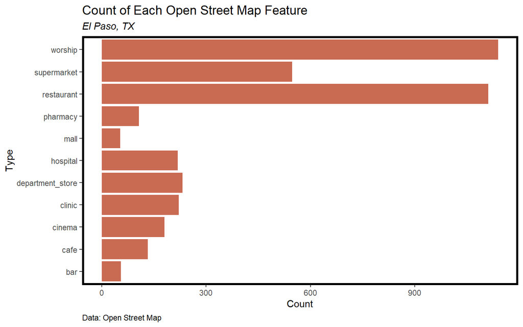

```r
osm_points_st <- osm_points %>%
  st_drop_geometry()

ggplot(osm_points_st, aes(y = type)) +
  geom_bar(fill = c(palette1)) +
  ggtitle("Count of Each Open Street Map Feature") +
  labs(subtitle="El Paso, TX",
       caption="Data: Open Street Map") +
  xlab("Count") +
  ylab("Type") +
  plotTheme
```

Below is a point-level distribution of each feature, separated into four maps with shared characteristics.

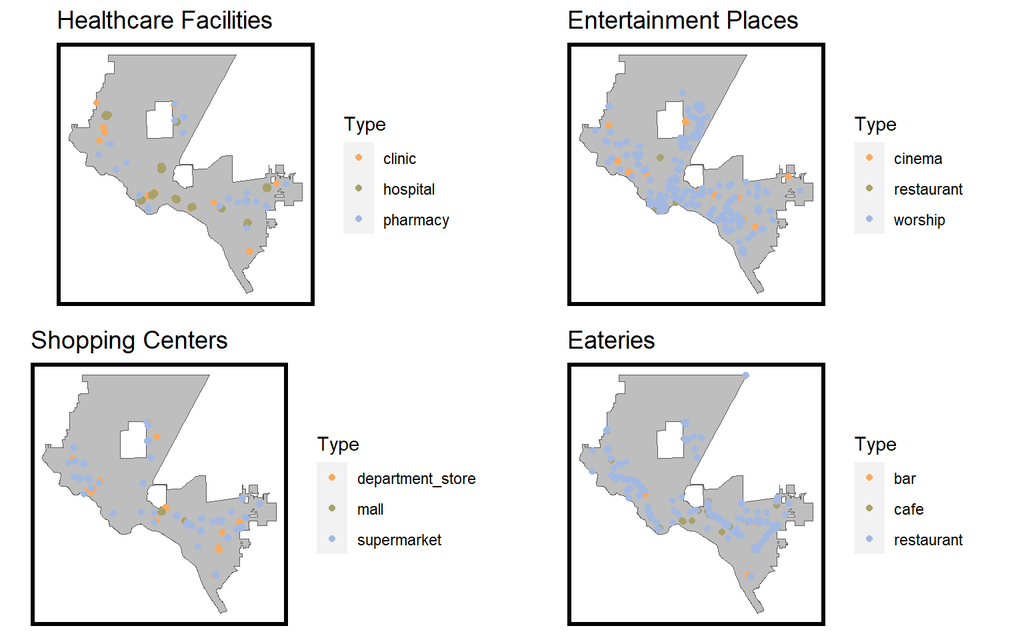

```r
health <- rbind(hospital_points, clinic_points, pharmacy_points)
entertainment <- rbind(worship_points, cinema_points, theatre_points)
shop <- rbind(department_store_points, supermarket_points, mall_points)
food <- rbind(restaurant_points, cafe_points, bar_points)

grid.arrange(
ggplot()+
  geom_sf(data=el_paso, fill="grey")+
  geom_sf(data=health, aes(color=type))+
  scale_color_manual(values=c(palette6[3:5]), name="Type")+
  labs(title="Healthcare Facilities")+
  mapTheme,
ggplot()+
  geom_sf(data=el_paso, fill="grey")+
  geom_sf(data=entertainment, aes(color=type))+
  scale_color_manual(values=c(palette6[3:5]), name="Type")+
  labs(title="Entertainment Places")+
  mapTheme,
ggplot()+
  geom_sf(data=el_paso, fill="grey")+
  geom_sf(data=shop, aes(color=type))+
  scale_color_manual(values=c(palette6[3:5]), name="Type")+
  labs(title="Shopping Centers")+
  mapTheme,
ggplot()+
  geom_sf(data=el_paso, fill="grey")+
  geom_sf(data=food, aes(color=type))+
  scale_color_manual(values=c(palette6[3:5]), name="Type")+
  labs(title="Eateries")+
  mapTheme,
ncol=2)
```

## Spatial Effects

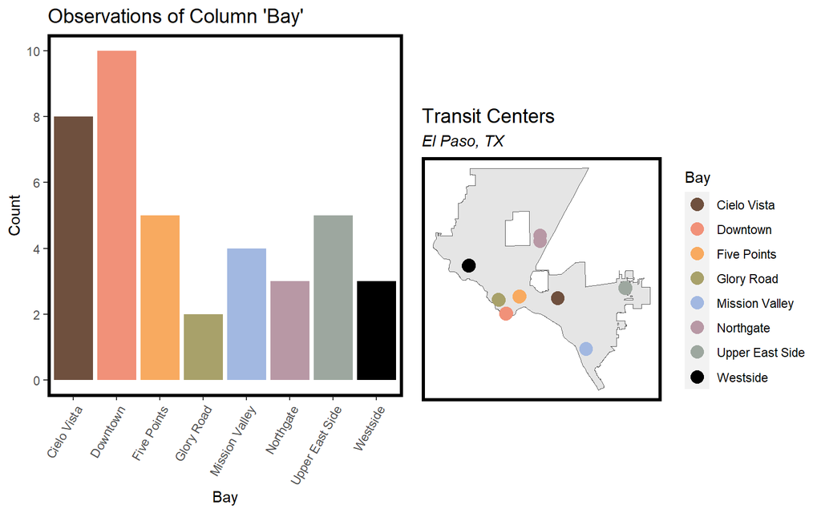

```r
library(dplyr)

bays <- local_transit_bays %>%
  mutate(Bay = ifelse(name == "BERT WILLIAMS DOWNTOWN SANTA FE TRANSIT CENTER", "Downtown",
                      ifelse(name == "ARTURO TURY BENAVIDES CIELO VISTA TRANSIT CENTER", "Cielo Vista",
                             ifelse(name == "UPPER EAST SIDE TRANSIT CENTER", "Upper East Side",
                                    ifelse(name == "ROBERT E. MCKEE FIVE POINTS TRANSIT CENTER", "Five Points",
                                           ifelse(name == "GLORY ROAD TRANSIT CENTER", "Glory Road",
                                                  ifelse(name == "NESTOR A. VALENCIA MISSION VALLEY TRANSIT CENTER", "Mission Valley",
                                                         ifelse(name == "ARVES E. JONES SR. TRANSIT CENTER AT NORTHGATE", "Northgate",
                                                                ifelse(name == "AL JEFFERSON WESTSIDE TRANSIT CENTER", "Westside", NA))))))))) %>%
  drop_na()

bays_st <- bays %>%
  st_drop_geometry()

bay1 <- ggplot(bays_st, aes(x = Bay)) +
  geom_bar(fill=c(palette8)) +
  labs(x = "Bay", y = "Count", title = "Observations of Column 'Bay'")+
  theme(axis.text.x = element_text(angle = 60, hjust = 1)) +
  scale_y_continuous(breaks = seq(0, 10, 2))+
  plotTheme


bay2 <- ggplot()+
  geom_sf(data=el_paso)+
  geom_sf(data=bays, aes(color=Bay), size=4)+
  scale_color_manual(values=palette8)+
  theme(legend.position = "right",
        legend.direction = "vertical")+
  labs(title="Transit Centers",
       subtitle = "El Paso, TX")+
  guides(color = guide_legend(override.aes = list(fill = palette8)))+
  mapTheme

bay_points <- local_transit_bays %>%
  dplyr::select("geometry") %>%
  mutate(type = "transit_bay")

grid.arrange(ncol=2, bay1, bay2)
```

# Modeling

## Building the hex grid

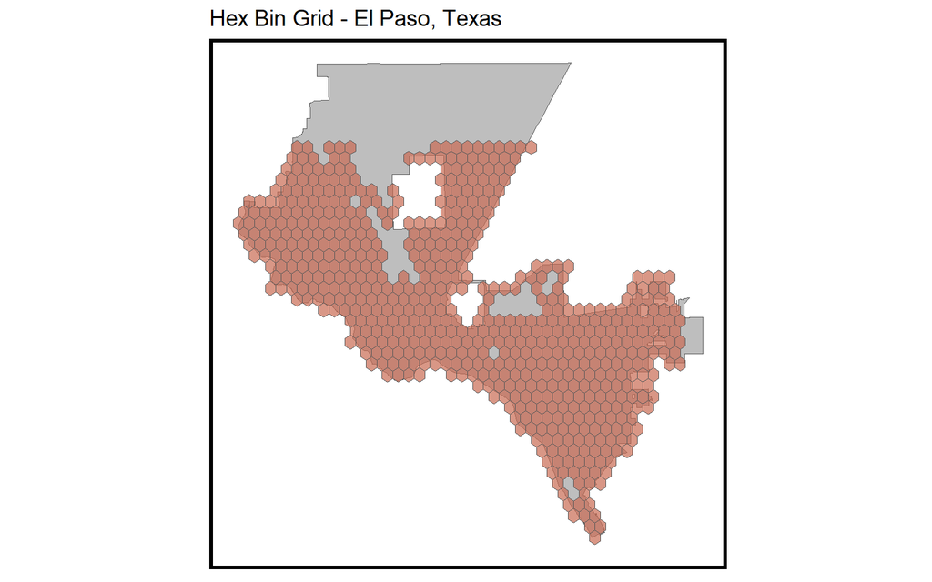

```r
bus_routes <- bus_routes %>%
  st_transform(crs=4269)

flum_crop <- flum %>%
  st_transform(crs=4269) %>%
  st_crop(y = st_bbox(bus_routes))

excludeLU <- c("Fort Bliss Military",
               "Fort Bliss Mixed Use (Airport)",
               "Preserve",
               "Industrial and/or Railyards",
               "Remote",
               "Military Reserve")

exclude_area <- flum_crop %>%
  filter(COMMENTS %in% excludeLU) %>%
  st_union()

el_paso <- el_paso %>%
  st_transform(crs=4269)

elpaso_outline <- el_paso %>%
  st_union() %>%
  st_sf() %>%
  st_crop(y = st_bbox(bus_routes)) %>%
  st_difference(exclude_area)

hex <- st_make_grid(elpaso_outline,
                    cellsize = .01,
                    crs = 4269,
                    square = F) %>%
  st_sf()

hex <- hex[elpaso_outline,] %>%
  mutate(uniqueID = rownames(.))

ggplot()+
  geom_sf(data=el_paso, fill='grey')+
  geom_sf(data=hex, fill=c(palette1), alpha=0.7)+
  labs(title="Hex Bin Grid - El Paso, Texas")+
  mapTheme
```

## Aggregated Ridership

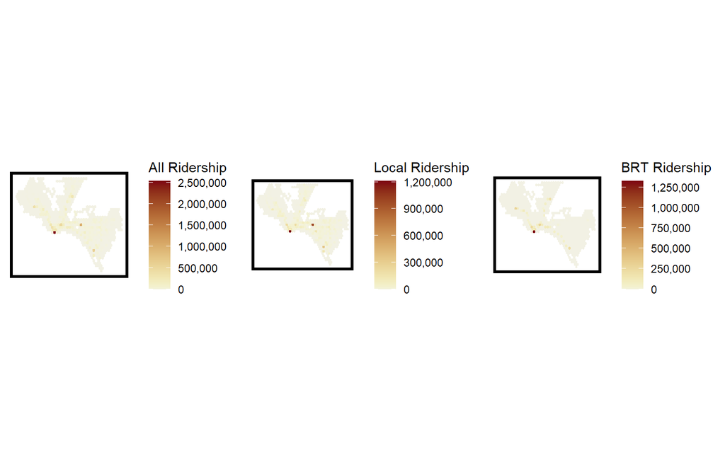

```r
riderstops_sf <- riderstops %>%
  filter(!is.na(stop_lat)) %>%
  st_as_sf(coords = c('stop_lon', 'stop_lat'), crs = 4269)

stop_riders_agg <- riderstops_sf %>%
  group_by(TP, RT) %>%
  summarise(ridership = sum(Ons) + sum(Offs))

stop_riders_agg_noBRT <- stop_riders_agg %>%
  filter(! RT %in% c(205,206,207,208))
stop_riders_agg_BRT <- stop_riders_agg %>%
  filter(RT %in% c(205,206,207,208))

ridership_net_local <- stop_riders_agg_noBRT %>% # Local Bus RT ridership
  dplyr::select(ridership) %>%
  aggregate(., hex, sum) %>%
  mutate(ridership = replace_na(ridership, 0),
         uniqueID = rownames(.))

ridership_net_all <- stop_riders_agg %>% # BRIO RT Ridership
  dplyr::select(ridership) %>%
  aggregate(., hex, sum) %>%
  mutate(ridership = replace_na(ridership, 0),
         uniqueID = rownames(.))

ridership_net_BRT <- stop_riders_agg_BRT %>%  # Total Ridership
  dplyr::select(ridership) %>%
  aggregate(., hex, sum) %>%
  mutate(ridership = replace_na(ridership, 0),
         uniqueID = rownames(.))

p1a <- ridership_net_local %>%
  ggplot()+
  geom_sf(aes(fill = ridership), color =NA)+
  paletteer::scale_fill_paletteer_c("grDevices::Red-Yellow", -1, labels= comma)+
  labs(fill = "Local Ridership")+
  theme(legend.position = 'right')+
  mapTheme


p1b <- ridership_net_all %>%
  ggplot()+
  geom_sf(aes(fill = ridership), color =NA)+
  paletteer::scale_fill_paletteer_c("grDevices::Red-Yellow", -1, labels= comma)+
  labs(fill = "All Ridership")+
  theme(legend.position = 'right')+
  mapTheme

p1c <- ridership_net_BRT %>%
  ggplot()+
  geom_sf(aes(fill = ridership), color =NA)+
  paletteer::scale_fill_paletteer_c("grDevices::Red-Yellow", -1, labels= comma)+
  labs(fill = "BRT Ridership")+
  theme(legend.position = 'right')+
  mapTheme

plot_grid(p1b,p1a,p1c, ncol=3)
```

```r
ep_work_census <- ep_work_census %>%
  dplyr::select(-c("GEOID", "NAME", "OBJECTID", "NAME.1", "GlobalID", "Shape_Length", "Shape_Area",
                   "year", "state", "age_29_or_younger", "age_30_to_54", "age_55_or_older", "monthly_income_1250_or_less", "monthly_income_1251_to_3333", "monthly_income_3334_or_more", "agriculture", "mining", "utilities", "construction", "manufacturing", "wholesaleTrade", "retailTrade", "transportationWarehousing", "informationTech", "financeInsurance", "realEstate", "techServices", "management", "wasteRemediation", "educational", "healthcareSocial", "artsEntertainmentRec", "foodServices", "otherJobs", "publicAdmin", "white_work", "black_work", "native_american_work", "asian_work", "pacific_work", "mixed_race_work", "not_hispanic_work", "hispanic_work", "underHS_work", "HS_work", "associate_work", "bachProfessional_work", "male_work", "female_work"))

ep_work_census <- ep_work_census %>%
  st_transform(crs=4269)

census_lehd_hex <- hex %>%
  st_centroid() %>%
  st_join(ep_work_census, join=st_within) %>%
  st_drop_geometry() %>%
  full_join(., hex) %>%
  st_sf()

nwi_bg <- nwi_bg %>%
  st_transform(crs=4269)

nwi_bg_hex <- nwi_bg %>%
  dplyr::select(-c("OBJECTID", "GEOID10", "TRACTCE", "BLKGRPCE", "totalPop", "GEOID", "OBJECTID.1", "NAME", "GlobalID", "Shape_Length", "Shape_Area"))

nwi_hex <- hex %>%
  st_centroid() %>%
  st_join(nwi_bg_hex, join=st_within)

final_hex <- left_join(ridership_net_local, st_drop_geometry(census_lehd_hex), by = "uniqueID") %>%
  left_join(st_drop_geometry(nwi_hex), by = "uniqueID") %>%
  replace(is.na(.), 0)

final_hex <- final_hex %>%
  st_sf() %>%
  dplyr::select(-c("area_sqmile"))

final_hex <- final_hex %>%
  mutate(nearestTransit = ifelse(nearestTransit == -99999.00, -1, nearestTransit),
         destinationAccessibility = ifelse(destinationAccessibility == -99999, 0, destinationAccessibility)) %>%
  dplyr::select(-c("B25044_001E"))

final_hex$uniqueID <- as.numeric(final_hex$uniqueID)
```

```r
schools_hex <- schools %>%
  st_transform(crs=4269) %>%
  dplyr::select(c("geometry")) %>%
  mutate(type = "school")

parks_hex <- parks %>%
  st_transform(crs=4269) %>%
  dplyr::select(c("geometry")) %>%
  mutate(type = "park")

major_hex <- major %>%
  dplyr::select(c("geometry")) %>%
  mutate(type="major_road") %>%
  st_transform(crs=4269)

vars_net <-
  rbind(
    schools_hex,
    parks_hex,
    major_hex,
    hospital_points,
    clinic_points,
    pharmacy_points,
    restaurant_points,
    cafe_points,
    bar_points,
    worship_points,
    cinema_points,
    theatre_points,
    department_store_points,
    supermarket_points,
    mall_points
) %>%
  st_join(., hex, join=st_within) %>%
  st_drop_geometry() %>%
  group_by(uniqueID, type) %>%
  summarize(count = n()) %>%
    full_join(hex) %>%
    spread(type, count, fill=0) %>%
    st_sf() %>%
    dplyr::select(-`<NA>`) %>%
    na.omit() %>%
    ungroup()

st_c <- st_coordinates
st_coid <- st_centroid

vars_net <-
  vars_net %>%
    mutate(
      schools.nn1 =
        nn_function(st_c(st_coid(vars_net)), st_c(schools_hex),1),
      schools.nn3 =
        nn_function(st_c(st_coid(vars_net)), st_c(schools_hex),3),
      schools.nn5 =
        nn_function(st_c(st_coid(vars_net)), st_c(schools_hex),5),
      parks.nn1 =
        nn_function(st_c(st_coid(vars_net)), st_c(st_coid(parks_hex)),1),
      parks.nn3 =
        nn_function(st_c(st_coid(vars_net)), st_c(st_coid(parks_hex)),3),
      parks.nn5 =
        nn_function(st_c(st_coid(vars_net)), st_c(st_coid(parks_hex)),5),
      hospitals.nn1 =
        nn_function(st_c(st_coid(vars_net)), st_c(hospital_points),1),
      hospitals.nn3 =
        nn_function(st_c(st_coid(vars_net)), st_c(hospital_points),3),
      hospitals.nn5 =
        nn_function(st_c(st_coid(vars_net)), st_c(hospital_points),5),
      clinics.nn1 =
        nn_function(st_c(st_coid(vars_net)), st_c(clinic_points),1),
      clinics.nn3 =
        nn_function(st_c(st_coid(vars_net)), st_c(clinic_points),3),
      clinics.nn5 =
        nn_function(st_c(st_coid(vars_net)), st_c(clinic_points),5),
      pharmacies.nn1 =
        nn_function(st_c(st_coid(vars_net)), st_c(pharmacy_points),1),
      pharmacies.nn3 =
        nn_function(st_c(st_coid(vars_net)), st_c(pharmacy_points),3),
      pharmacies.nn5 =
        nn_function(st_c(st_coid(vars_net)), st_c(pharmacy_points),5),
      restaurants.nn1 =
        nn_function(st_c(st_coid(vars_net)), st_c(restaurant_points),1),
      restaurants.nn3 =
        nn_function(st_c(st_coid(vars_net)), st_c(restaurant_points),3),
      restaurants.nn5 =
        nn_function(st_c(st_coid(vars_net)), st_c(restaurant_points),5),
      cafes.nn1 =
        nn_function(st_c(st_coid(vars_net)), st_c(cafe_points),1),
      cafes.nn3 =
        nn_function(st_c(st_coid(vars_net)), st_c(cafe_points),3),
      cafes.nn5 =
        nn_function(st_c(st_coid(vars_net)), st_c(cafe_points),5),
      bars.nn1 =
        nn_function(st_c(st_coid(vars_net)), st_c(bar_points),1),
      bars.nn3 =
        nn_function(st_c(st_coid(vars_net)), st_c(bar_points),3),
      bars.nn5 =
        nn_function(st_c(st_coid(vars_net)), st_c(bar_points),5),
      worship_places.nn1 =
        nn_function(st_c(st_coid(vars_net)), st_c(worship_points),1),
      worship_places.nn3 =
        nn_function(st_c(st_coid(vars_net)), st_c(worship_points),3),
      worship_places.nn5 =
        nn_function(st_c(st_coid(vars_net)), st_c(worship_points),5),
      cinemas.nn1 =
        nn_function(st_c(st_coid(vars_net)), st_c(cinema_points),1),
      cinemas.nn3 =
        nn_function(st_c(st_coid(vars_net)), st_c(cinema_points),3),
      cinemas.nn5 =
        nn_function(st_c(st_coid(vars_net)), st_c(cinema_points),5),
      theatres.nn1 =
        nn_function(st_c(st_coid(vars_net)), st_c(theatre_points),1),
      theatres.nn3 =
        nn_function(st_c(st_coid(vars_net)), st_c(theatre_points),3),
      theatres.nn5 =
        nn_function(st_c(st_coid(vars_net)), st_c(theatre_points),5),
      department_stores.nn1 =
        nn_function(st_c(st_coid(vars_net)), st_c(department_store_points),1),
      department_stores.nn3 =
        nn_function(st_c(st_coid(vars_net)), st_c(department_store_points),3),
      department_stores.nn5 =
        nn_function(st_c(st_coid(vars_net)), st_c(department_store_points),5),
      supermarkets.nn1 =
        nn_function(st_c(st_coid(vars_net)), st_c(supermarket_points),1),
      supermarkets.nn3 =
        nn_function(st_c(st_coid(vars_net)), st_c(supermarket_points),3),
      supermarkets.nn5 =
        nn_function(st_c(st_coid(vars_net)), st_c(supermarket_points),5),
      malls.nn1 =
        nn_function(st_c(st_coid(vars_net)), st_c(mall_points),1),
      malls.nn3 =
        nn_function(st_c(st_coid(vars_net)), st_c(mall_points),3),
      malls.nn5 =
        nn_function(st_c(st_coid(vars_net)), st_c(mall_points),5),
      major_road.nn1 =
        nn_function(st_c(st_coid(vars_net)), st_c(st_coid(major_hex)),1),
      major_road.nn3 =
        nn_function(st_c(st_coid(vars_net)), st_c(st_coid(major_hex)),3),
      major_road.nn5 =
        nn_function(st_c(st_coid(vars_net)), st_c(st_coid(major_hex)),5)
    )

vars_net <- vars_net %>%
  st_drop_geometry()

final_hex <- merge(final_hex, vars_net, by = "uniqueID")
```